# Hyperlipidemia Temperature Statistical Testing

Analysis of diagnosis-prediction model discrimination, AI-agent temperature sensitivity, and calibration

Rayan Tahir

July 27, 2026

## **Executive Summary**

**In plain terms:** this report checks whether the diagnosis-prediction models tested (Random Forest, XGBoost, and Logistic Regression, plus SVM and Gradient Boosting where sample size allowed) actually predict hyperlipidemia better than random guessing, whether the AI agent’s “temperature” setting (a parameter controlling how much randomness the agent uses when writing the code that implements these models) changes how well the resulting diagnosis-prediction models perform, and which diagnosis-prediction model performs best overall.

**A note on terminology used throughout this report**  
This project involves two distinct layers:

- **Diagnosis-prediction models**: the actual statistical/machine learning classifiers being evaluated (ex: Random Forest, XGBoost, Logistic Regression, SVM, Gradient Boosting). These are what “AUROC,” “Brier score,” and “most accurate model” refer to throughout this report.
- **The AI agent / LLM framework**: the large language model (gpt-5.4) that searches for candidate diagnosis-prediction models, writes the code implementing them, and evaluates them. Temperature is a setting of this agent, controlling how much randomness it uses when generating that code. It is not a hyperparameter of the diagnosis-prediction models themselves.

The term “significantly better than chance” in this report specifically indicate a diagnosis-prediction model’s ability to distinguish patients who do and do not have **hyperlipidemia**, not any other diagnosis or condition. This choice was consistent across all testing.

**Better than chance** Most adequately sampled diagnosis-prediction model / temperature combinations predicted hyperlipidemia significantly better than random guessing (AUROC significantly above 0.5).

**Temperature effect** The AI agent’s temperature setting was significantly associated with performance for XGBoost only.

**Calibration** Random Forest generally had the lowest (best) Brier scores.

**Overall conclusion:** The AI agent’s temperature setting did not consistently affect the three primary diagnosis-prediction models’ performance, although XGBoost showed evidence of temperature sensitivity.

## Study Overview

**Experimental design**

| Diagnosis being predicted | Hyperlipidemia |
| --- | --- |
| AI agent temperatures tested | 0.1, 0.5, 0.7, 0.9 |
| Primary diagnosis-prediction models | Random Forest, XGBoost, Logistic Regression |
| Repetitions per temperature | 10 |
| Primary performance metric | AUROC (discrimination) |
| Calibration metric | Brier score |

SVM and Gradient Boosting were also selected by the literature-search process in some runs, but were tested far less consistently than the three primary diagnosis-prediction models. They are excluded from the temperature-effect analysis (Question 2) and the model-comparison analysis (Question 3) because their available sample sizes were insufficient for reliable comparison. Their descriptive results are reported in Appendix B.

**Glossary (click to expand plain-English definitions)**

**Basic performance terms**

**Statistical testing terms**

- **p-value**: roughly, “if there were truly no real difference, how surprising would this result be?” A p-value below 0.05 (the standard cutoff used throughout this report) is treated as evidence a real difference exists. A p-value above 0.05 does not prove there’s no difference, it just means this data isn’t enough to confidently say there is one.
- **Statistically significant**: shorthand for “the p-value cleared the 0.05 cutoff.” It is a statement about confidence, not about how large or important the difference is.
- **Confidence interval (CI)**: a range that likely contains the true value, given the data collected. A “95% CI” means: if this whole study were repeated many times, about 95% of the intervals calculated this way would contain the true answer. A narrower interval means a more precise estimate.
- **One-sample t-test**: used to test whether a diagnosis-prediction model’s average AUROC is significantly different from 0.5 (chance).
- **ANOVA (Analysis of Variance)**: tests whether a variable (here, the AI agent’s temperature setting) causes real differences across more than two groups. Answers “does temperature matter at all,” not which specific temperature differs.
- **Two-sided vs. one-sided test**: a two-sided test checks for a difference in either direction; a one-sided test only checks one specific direction. Two-sided is the more conservative, honest default unless a specific direction was decided *before* looking at the data, which is why every test in this report is two-sided.
- **Multiple comparisons correction (Holm correction)**: if you run several statistical tests at once, some will look “significant” just by chance, the same way flipping a coin 20 times will probably give you a suspicious-looking streak somewhere. Holm correction adjusts the p-values to account for how many comparisons were run, so the results stay trustworthy even when testing several things together.

**Mixed-effects model terms (used in Question 3)**

- **Mixed-effects model**: a more advanced version of the tests above, used when some data points aren’t fully independent of each other. **This does NOT mean the diagnosis-prediction models communicate or remember each other**: each one is trained completely separately, with no shared state. What they *do* share is the data preparation that happens once per AI agent run, before any diagnosis-prediction model is trained: the patient data is pulled from raw clinical records, features (like BMI or glucose) are extracted from it, and patients are split into train/test groups. All diagnosis-prediction models selected in a given AI agent run are handed that same prepared dataset. That preparation code is written fresh by the AI agent every run rather than being one fixed script, so its quality varies run to run: one run’s data prep might do a thorough job, another might miss things or handle messy records differently. Whatever quality a given run’s preparation happened to have becomes a shared advantage or disadvantage for every diagnosis-prediction model tested in that run, purely because they were all handed the same starting materials. (Analogy: three students independently taking the same exam on a day the fire alarm went off twice. They didn’t help each other, but all three scores were still affected by the same disruption.) A regular test that assumes full independence would mistake some of that shared “good run” or “bad run” luck for a genuine difference between diagnosis-prediction models. This model is built specifically to separate the two apart.
- **Fixed effect**: the thing you actually want to measure and compare (here: which diagnosis-prediction model, and which AI agent temperature setting).
- **Random effect**: something you know adds variability but aren’t trying to individually measure. You just want the model to account for it. Here, that’s “which AI agent run the data came from”: some runs had better or worse data preparation, affecting every diagnosis-prediction model tested in them, and this prevents that from distorting the model comparison.
- **Estimated marginal means (EMM)**: the “adjusted average” score for each diagnosis-prediction model once the mixed-effects model has accounted for AI agent temperature and the run-level effect above. This is the fair, apples-to-apples number used to rank the diagnosis-prediction models, rather than a simple raw average.

## Research questions

1. **Do the diagnosis-prediction models predict hyperlipidemia significantly better than random chance?**
2. **Does the AI agent’s temperature setting affect diagnosis-prediction model performance?**
3. **Which diagnosis-prediction model is most accurate, and does calibration differ between them?**

# Results

## Question 1: Do the diagnosis-prediction models perform better than chance?

**Research Question 1**  
Is each diagnosis-prediction model’s ability to discriminate hyperlipidemia patients from non-hyperlipidemia patients (AUROC) significantly better than random guessing (0.5)?

**Method:** One-sample t-tests comparing each diagnosis-prediction model’s mean AUROC for predicting hyperlipidemia to 0.5, separately for every AI agent temperature setting tested.

**Result:** 11 of 17 testable diagnosis-prediction model / temperature combinations predicted hyperlipidemia significantly better than random guessing. 3 combination(s) had too little data to test at all.

One-sample t-tests: mean AUROC vs. 0.5, by diagnosis-prediction model and AI agent temperature

| temperature | model | n | auroc_mean | t | df | p_value | significant |
| --- | --- | --- | --- | --- | --- | --- | --- |
| 0.1 | logistic_regression | 7 | 0.5537 | 3.7753 | 6 | 0.0092 | TRUE |
| 0.1 | random_forest | 10 | 0.5772 | 7.0619 | 9 | 0.0001 | TRUE |
| 0.1 | xgboost | 9 | 0.5828 | 9.1325 | 8 | 0.0000 | TRUE |
| 0.1 | svm | 3 | 0.4943 | -0.6296 | 2 | 0.5933 | FALSE |
| 0.1 | gradient_boosting | 1 | 0.6114 | NA | NA | NA | FALSE |
| 0.5 | random_forest | 10 | 0.5899 | 10.7161 | 9 | 0.0000 | TRUE |
| 0.5 | xgboost | 8 | 0.5789 | 8.5154 | 7 | 0.0001 | TRUE |
| 0.5 | logistic_regression | 9 | 0.5397 | 4.9654 | 8 | 0.0011 | TRUE |
| 0.5 | gradient_boosting | 1 | 0.6083 | NA | NA | NA | FALSE |
| 0.5 | svm | 2 | 0.5211 | 1.0000 | 1 | 0.5000 | FALSE |
| 0.7 | logistic_regression | 7 | 0.5277 | 6.6462 | 6 | 0.0006 | TRUE |
| 0.7 | random_forest | 10 | 0.5942 | 14.1181 | 9 | 0.0000 | TRUE |
| 0.7 | svm | 4 | 0.5125 | 0.6114 | 3 | 0.5842 | FALSE |
| 0.7 | xgboost | 6 | 0.5951 | 13.8949 | 5 | 0.0000 | TRUE |
| 0.7 | gradient_boosting | 3 | 0.5959 | 3.3592 | 2 | 0.0783 | FALSE |
| 0.9 | logistic_regression | 8 | 0.5264 | 3.7109 | 7 | 0.0075 | TRUE |
| 0.9 | random_forest | 10 | 0.5661 | 6.2082 | 9 | 0.0002 | TRUE |
| 0.9 | xgboost | 9 | 0.5414 | 2.1150 | 8 | 0.0673 | FALSE |
| 0.9 | gradient_boosting | 1 | 0.5725 | NA | NA | NA | FALSE |
| 0.9 | svm | 2 | 0.5368 | 1.1754 | 1 | 0.4488 | FALSE |

### Interpretation

**Combinations that could not be tested (only 1 observation):** Gradient Boosting at temperature 0.1; Gradient Boosting at temperature 0.5; Gradient Boosting at temperature 0.9

**Combinations where AUROC was not significantly different from chance:** SVM at temperature 0.1 (AUROC = 0.494, p = 0.5933); SVM at temperature 0.5 (AUROC = 0.521, p = 0.5000); SVM at temperature 0.7 (AUROC = 0.513, p = 0.5842); Gradient Boosting at temperature 0.7 (AUROC = 0.596, p = 0.0783); XGBoost at temperature 0.9 (AUROC = 0.541, p = 0.0673); SVM at temperature 0.9 (AUROC = 0.537, p = 0.4488)

The remaining 11 of 17 testable combinations showed AUROC significantly above chance for predicting hyperlipidemia. This confirms these diagnosis-prediction models are picking up genuine, non-random signal, even though (as later sections discuss) the size of that signal is modest.

## Question 2: Does AI agent temperature affect diagnosis-prediction model performance?

**Research Question 2**  
Does the AI agent’s temperature setting (how much randomness it uses when writing the code that implements each diagnosis-prediction model) significantly change how well the resulting diagnosis-prediction models perform?

**Method:** Separate one-way ANOVAs compared mean AUROC across the four AI agent temperature settings, for each of the three primary diagnosis-prediction models.

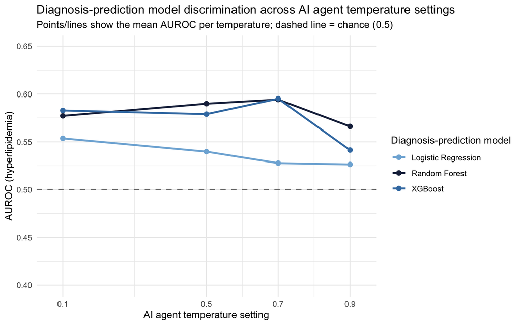

**Result:** The AI agent’s temperature setting was significantly associated with AUROC for XGBoost, but not the other primary diagnosis-prediction models.

Effect of AI agent temperature on AUROC by diagnosis-prediction model

|  | Model | F statistic | p-value | Conclusion |
| --- | --- | --- | --- | --- |
| random_forest | Random Forest | 1.877 | 0.1510 | No significant effect |
| xgboost | XGBoost | 3.074 | 0.0438 | Significant temperature effect |
| logistic_regression | Logistic Regression | 1.898 | 0.1538 | No significant effect |

### Interpretation

Random Forest showed no significant AI agent temperature effect (F(3,36) = 1.877, p = 0.1510). Differences across settings are consistent with ordinary run-to-run variation.XGBoost showed a statistically significant AI agent temperature effect (F(3,28) = 3.074, p = 0.0438). Logistic Regression showed no significant AI agent temperature effect (F(3,27) = 1.898, p = 0.1538). Differences across settings are consistent with ordinary run-to-run variation.

## Question 3: Which diagnosis-prediction model is most accurate, and does calibration differ?

**Research Question 3**  
Which diagnosis-prediction model has the best discrimination (AUROC) overall for predicting hyperlipidemia, and does calibration (Brier score) differ between diagnosis-prediction models? Comparisons use a mixed-effects model on the raw per-run data.

### Why a mixed-effects model instead of simpler tests

When two or three diagnosis-prediction models are all tested within the *same* AI agent run, they don’t communicate or remember each other – each is trained completely separately. But they are handed the same prepared patient data for that run, and that preparation is written fresh by the AI agent each run, so its quality varies. A simpler test can’t tell the difference between “this diagnosis-prediction model is genuinely better” and “this diagnosis-prediction model happened to get tested on a run with better data prep.” The mixed-effects model explicitly separates those two things out. See the Glossary for a fuller explanation with an analogy.

**The model fit, in equation form** (the same structure is used for both AUROC and Brier score):

$$\text{metric} \sim \text{model} +
\text{temperature} + (1 \mid \text{run\_id})$$

- **metric**: the outcome being predicted: AUROC in one model, Brier score in the other
- **model**: fixed effect for which of the three diagnosis-prediction algorithms produced that observation
- **temperature**: fixed effect for which of the four AI agent temperature settings that run used
- **(1 | run_id)**: random intercept per AI agent run, accounting for the shared “which run’s data prep was this” effect described above

In R, this was fit using `lme4::lmer()` as: `lmer(auroc ~ model_family + temperature + (1 | run_id), data = well_sampled_raw)` (and the equivalent with `brier` as the outcome for the calibration model).

AUROC: estimated marginal means, adjusted for AI agent temperature and run-level clustering (95% CI)

| model | emmean | SE | lower.CL | upper.CL |
| --- | --- | --- | --- | --- |
| Random Forest | 0.5818 | 0.0050 | 0.5719 | 0.5918 |
| XGBoost | 0.5739 | 0.0056 | 0.5629 | 0.5849 |
| Logistic Regression | 0.5382 | 0.0056 | 0.5270 | 0.5494 |

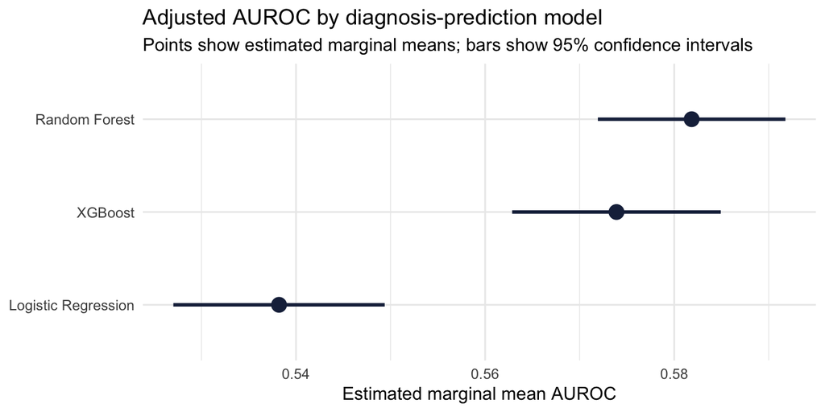

Brier score: estimated marginal means, lower is better (95% CI)

| model | emmean | SE | lower.CL | upper.CL |
| --- | --- | --- | --- | --- |
| Random Forest | 0.2179 | 0.0058 | 0.2063 | 0.2295 |
| XGBoost | 0.2457 | 0.0066 | 0.2327 | 0.2587 |
| Logistic Regression | 0.3224 | 0.0067 | 0.3091 | 0.3356 |

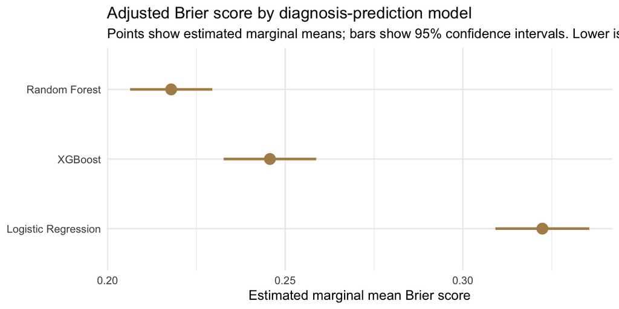

**Result:** Random Forest had the highest adjusted AUROC (EMM = 0.582). Random Forest had the best (lowest) adjusted Brier score (EMM = 0.218).

AUROC pairwise comparisons (Holm-corrected, two-sided)

| contrast | estimate | SE | df | p.value |
| --- | --- | --- | --- | --- |
| random_forest - xgboost | 0.0080 | 0.0064 | 66.9383 | 0.2217 |
| random_forest - logistic_regression | 0.0436 | 0.0065 | 67.4800 | 0.0000 |
| xgboost - logistic_regression | 0.0357 | 0.0068 | 64.4671 | 0.0000 |

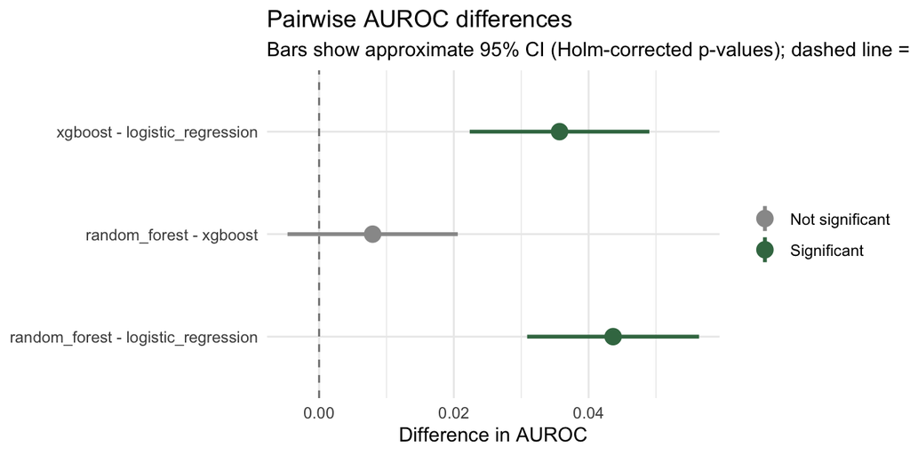

Brier score pairwise comparisons (Holm-corrected, two-sided)

| contrast | estimate | SE | df | p.value |
| --- | --- | --- | --- | --- |
| random_forest - xgboost | -0.0278 | 0.0088 | 69.0105 | 0.0023 |
| random_forest - logistic_regression | -0.1044 | 0.0088 | 69.7540 | 0.0000 |
| xgboost - logistic_regression | -0.0767 | 0.0093 | 67.2899 | 0.0000 |

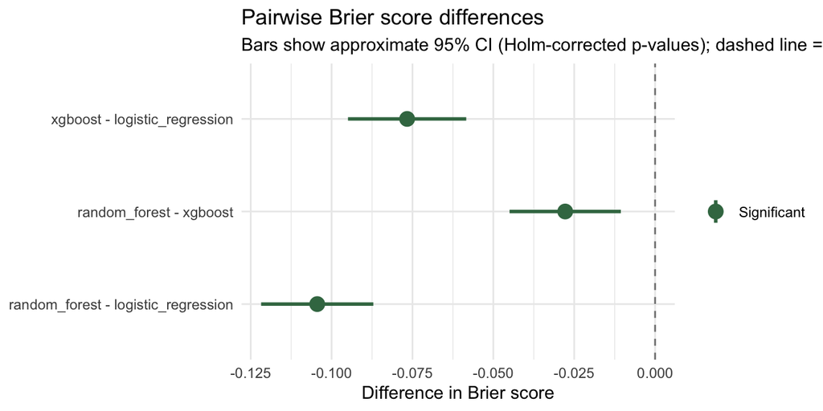

### Interpretation

**Random Forest vs. XGBoost** Ranking ability (AUROC) was not significantly different (p = 0.2217). These two diagnosis-prediction models cannot be confidently distinguished on discrimination alone. Random Forest gives significantly more trustworthy probability estimates (lower Brier score, p = 0.0023). **Practical takeaway:** since ranking ability alone cannot separate these two, Random Forest’s meaningfully better calibration is what actually tips the practical recommendation in its favor.

**Random Forest vs. Logistic Regression** Random Forest ranks patients significantly better (higher AUROC, Holm-adjusted p = 0.0000). Random Forest gives significantly more trustworthy probability estimates (lower Brier score, p = 0.0000). **Practical takeaway:** Random Forest is the clearer choice of the two: it wins on both ranking ability and calibration.

**XGBoost vs. Logistic Regression** XGBoost ranks patients significantly better (higher AUROC, Holm-adjusted p = 0.0000). XGBoost gives significantly more trustworthy probability estimates (lower Brier score, p = 0.0000). **Practical takeaway:** XGBoost is the clearer choice of the two: it wins on both ranking ability and calibration.

# Conclusions

**Do the diagnosis-prediction models actually predict hyperlipidemia better than guessing?** Yes, in most cases: 11 out of 17 testable diagnosis-prediction model / AI agent temperature combinations performed significantly better than random guessing.

**Does the AI agent’s temperature setting change diagnosis-prediction model performance?** Partially: XGBoost showed a real, statistically confirmed change; the other diagnosis-prediction models did not.

**Which diagnosis-prediction model is most accurate?** Random Forest, based on the highest adjusted AUROC.

**Which diagnosis-prediction model gives the most trustworthy probability estimates?** Random Forest, based on the lowest adjusted Brier score.

# Limitations

- Questions 1 and 2 are computed from summary statistics (mean, standard deviation, n) per diagnosis-prediction model / AI agent temperature cell. Question 3 uses the raw, per-run observations so it could properly account for run-level clustering via the mixed-effects model.
- SVM and Gradient Boosting were excluded from Questions 2 and 3 due to insufficient sample sizes; see Appendix B for their descriptive results.
- A significant omnibus ANOVA result (Question 2) only shows that AI agent temperature matters *somewhere* across the four settings, not which specific pair of temperatures differs.

**Detailed methodological limitations**

- Tests in Questions 1 and 2 were calculated from summary statistics rather than raw run-level results, which is standard practice (comparable to methods used in meta-analysis) but does not capture within-run pairing the way Question 3’s mixed-effects model does.
- The mixed-effects analysis in Question 3 requires the `lme4` and `emmeans` packages. If unavailable, a dependency-free fallback (base R only) is: `aov(auroc ~ model_family + temperature, data = raw_long)` followed by `pairwise.t.test(..., p.adjust.method = "holm")`. This loses the run-level random effect but still uses real raw data with Holm-corrected comparisons.
- Cells with very small sample sizes (as few as 1 repetition) have very limited statistical power; where n = 1, a t-test cannot be computed at all (a standard deviation requires at least 2 observations) and is marked as untestable rather than silently omitted.
- The AUROC-vs-chance test uses the standard 0.5 threshold for random guessing, which is appropriate for a ranking test independent of class imbalance.

# Appendix A: Complete descriptive statistics

All diagnosis-prediction model / AI agent temperature summary statistics (mean (sd)), all five models

| Temperature | Model | n | Accuracy | F1 | Precision | Recall | AUROC | Brier |
| --- | --- | --- | --- | --- | --- | --- | --- | --- |
| 0.1 | Logistic Regression | 7 | 0.354 (0.034) | 0.494 (0.012) | 0.333 (0.010) | 0.956 (0.047) | 0.554 (0.038) | 0.303 (0.071) |
| 0.1 | Random Forest | 10 | 0.384 (0.070) | 0.489 (0.012) | 0.339 (0.017) | 0.898 (0.119) | 0.577 (0.035) | 0.218 (0.005) |
| 0.1 | XGBoost | 9 | 0.397 (0.082) | 0.492 (0.016) | 0.345 (0.023) | 0.893 (0.149) | 0.583 (0.027) | 0.247 (0.011) |
| 0.1 | SVM | 3 | 0.335 (0.013) | 0.496 (0.006) | 0.331 (0.005) | 0.996 (0.007) | 0.494 (0.016) | 0.221 (0.000) |
| 0.1 | Gradient Boosting | 1 | 0.337 (0.000) | 0.498 (0.000) | 0.332 (0.000) | 1.000 (0.000) | 0.611 (0.000) | 0.217 (0.000) |
| 0.5 | Random Forest | 10 | 0.398 (0.068) | 0.487 (0.034) | 0.341 (0.014) | 0.880 (0.164) | 0.590 (0.027) | 0.218 (0.005) |
| 0.5 | XGBoost | 8 | 0.371 (0.047) | 0.500 (0.008) | 0.340 (0.013) | 0.955 (0.046) | 0.579 (0.026) | 0.248 (0.010) |
| 0.5 | Logistic Regression | 9 | 0.351 (0.028) | 0.493 (0.009) | 0.332 (0.007) | 0.959 (0.048) | 0.540 (0.024) | 0.348 (0.057) |
| 0.5 | Gradient Boosting | 1 | 0.378 (0.000) | 0.505 (0.000) | 0.342 (0.000) | 0.963 (0.000) | 0.608 (0.000) | 0.219 (0.000) |
| 0.5 | SVM | 2 | 0.331 (0.003) | 0.496 (0.001) | 0.330 (0.001) | 1.000 (0.000) | 0.521 (0.030) | 0.221 (0.000) |
| 0.7 | Logistic Regression | 7 | 0.353 (0.017) | 0.483 (0.009) | 0.328 (0.005) | 0.917 (0.042) | 0.528 (0.011) | 0.383 (0.018) |
| 0.7 | Random Forest | 10 | 0.352 (0.031) | 0.492 (0.005) | 0.332 (0.006) | 0.953 (0.054) | 0.594 (0.021) | 0.216 (0.003) |
| 0.7 | SVM | 4 | 0.341 (0.022) | 0.480 (0.031) | 0.325 (0.010) | 0.932 (0.136) | 0.513 (0.041) | 0.221 (0.000) |
| 0.7 | XGBoost | 6 | 0.412 (0.055) | 0.503 (0.008) | 0.350 (0.015) | 0.901 (0.062) | 0.595 (0.017) | 0.244 (0.010) |
| 0.7 | Gradient Boosting | 3 | 0.371 (0.022) | 0.500 (0.020) | 0.339 (0.013) | 0.955 (0.050) | 0.596 (0.049) | 0.233 (0.035) |
| 0.9 | Logistic Regression | 8 | 0.370 (0.057) | 0.488 (0.012) | 0.335 (0.015) | 0.912 (0.096) | 0.526 (0.020) | 0.256 (0.056) |
| 0.9 | Random Forest | 10 | 0.354 (0.038) | 0.493 (0.010) | 0.333 (0.010) | 0.953 (0.059) | 0.566 (0.034) | 0.220 (0.004) |
| 0.9 | XGBoost | 9 | 0.381 (0.047) | 0.485 (0.048) | 0.334 (0.024) | 0.896 (0.157) | 0.541 (0.059) | 0.237 (0.015) |
| 0.9 | Gradient Boosting | 1 | 0.346 (0.000) | 0.502 (0.000) | 0.335 (0.000) | 1.000 (0.000) | 0.572 (0.000) | 0.223 (0.000) |
| 0.9 | SVM | 2 | 0.337 (0.006) | 0.494 (0.005) | 0.330 (0.001) | 0.981 (0.026) | 0.537 (0.044) | 0.220 (0.000) |

# Appendix B: Additional statistical output (all five models, including SVM and Gradient Boosting)

One-sample t-tests vs. chance, all five diagnosis-prediction models

| temperature | model | n | auroc_mean | t | df | p_value | significant | testable |
| --- | --- | --- | --- | --- | --- | --- | --- | --- |
| 0.1 | logistic_regression | 7 | 0.5537 | 3.7753 | 6 | 0.0092 | TRUE | TRUE |
| 0.1 | random_forest | 10 | 0.5772 | 7.0619 | 9 | 0.0001 | TRUE | TRUE |
| 0.1 | xgboost | 9 | 0.5828 | 9.1325 | 8 | 0.0000 | TRUE | TRUE |
| 0.1 | svm | 3 | 0.4943 | -0.6296 | 2 | 0.5933 | FALSE | TRUE |
| 0.1 | gradient_boosting | 1 | 0.6114 | NA | NA | NA | FALSE | FALSE |
| 0.5 | random_forest | 10 | 0.5899 | 10.7161 | 9 | 0.0000 | TRUE | TRUE |
| 0.5 | xgboost | 8 | 0.5789 | 8.5154 | 7 | 0.0001 | TRUE | TRUE |
| 0.5 | logistic_regression | 9 | 0.5397 | 4.9654 | 8 | 0.0011 | TRUE | TRUE |
| 0.5 | gradient_boosting | 1 | 0.6083 | NA | NA | NA | FALSE | FALSE |
| 0.5 | svm | 2 | 0.5211 | 1.0000 | 1 | 0.5000 | FALSE | TRUE |
| 0.7 | logistic_regression | 7 | 0.5277 | 6.6462 | 6 | 0.0006 | TRUE | TRUE |
| 0.7 | random_forest | 10 | 0.5942 | 14.1181 | 9 | 0.0000 | TRUE | TRUE |
| 0.7 | svm | 4 | 0.5125 | 0.6114 | 3 | 0.5842 | FALSE | TRUE |
| 0.7 | xgboost | 6 | 0.5951 | 13.8949 | 5 | 0.0000 | TRUE | TRUE |
| 0.7 | gradient_boosting | 3 | 0.5959 | 3.3592 | 2 | 0.0783 | FALSE | TRUE |
| 0.9 | logistic_regression | 8 | 0.5264 | 3.7109 | 7 | 0.0075 | TRUE | TRUE |
| 0.9 | random_forest | 10 | 0.5661 | 6.2082 | 9 | 0.0002 | TRUE | TRUE |
| 0.9 | xgboost | 9 | 0.5414 | 2.1150 | 8 | 0.0673 | FALSE | TRUE |
| 0.9 | gradient_boosting | 1 | 0.5725 | NA | NA | NA | FALSE | FALSE |
| 0.9 | svm | 2 | 0.5368 | 1.1754 | 1 | 0.4488 | FALSE | TRUE |

One-way ANOVA across AI agent temperature, all five diagnosis-prediction models (low_power_warning = TRUE means a temperature cell had only 1 repetition)

| model | min_n | F | df_between | df_within | p_value | significant | low_power_warning |
| --- | --- | --- | --- | --- | --- | --- | --- |
| random_forest | 10 | 1.8767 | 3 | 36 | 0.1510 | FALSE | FALSE |
| xgboost | 6 | 3.0740 | 3 | 28 | 0.0438 | TRUE | FALSE |
| logistic_regression | 7 | 1.8975 | 3 | 27 | 0.1538 | FALSE | FALSE |
| svm | 2 | 0.6453 | 3 | 7 | 0.6101 | FALSE | FALSE |
| gradient_boosting | 1 | 0.1279 | 3 | 2 | 0.9354 | FALSE | TRUE |

# Appendix C: Analysis code

All code used to produce this report is embedded in the `.Rmd` source file. Code output is hidden by default in this rendered report to keep the focus on findings; each section’s underlying code can be viewed by opening the `.Rmd` file directly, or by changing `echo = FALSE` to `echo = TRUE` in the setup chunk and re-knitting.